# Cut Claude Code Token Usage by 90%

# Cut Claude Code Token Usage by 90%: 4 Strategies

**Source:** YouTube screen-recording tutorial — youtu.be/UslVzxAkiZ0 **Presenter:** John Kim *(getpushtoprod.substack.com)* **Runtime:** ~20m 31s **Figures:** 10 slides and live-demo screenshots drawn from the recording

> This is a lightly cleaned, verbatim transcript of a single-narrator tutorial. Filler words, false starts, and dead repetition have been removed; the speaker’s words and phrasing are otherwise preserved. Timestamps (`*[~MM:SS]*`) mark roughly five-minute intervals. Transcription artifacts were corrected: “clock/cloud code” → **Claude Code**, “curie/curry” → **query**, “code graph” → **CodeGraph / `codegraph`**, “RTX” → **RTK** (the tool he first names “rtk”), “Cavemen” → **caveman**, “weigh in” → **wenyan** (the caveman mode), and “rack” → **RAG**. A stuck-audio passage near 16:00 (the phrase “I want to go ahead and do that” looping) was removed as a recording glitch.

## Contents

- Introduction
- Strategy 1: Index the Code with CodeGraph
  - Grep and Scan vs Query the Graph
  - Using CodeGraph
  - Trade-offs of Indexing
- Strategy 2: Compress the Outputs with RTK
  - Trade-off: Lossy Compression
- Strategy 3: Make Claude Talk Less with caveman
  - Trade-off: Context Quality
- Strategy 4: Manage the Session
  - Context, Clear, and Model
  - Pro Tips
- Should You Use All of These?
- Conclusion
- Key Takeaways

## Introduction

*[~0:00]*

I’m going to teach you how to reduce your Claude Code token usage by **up to 90%** with four different strategies. It’s easy and free to do, and you can do it right away. I’ll show you step by step, with a quick visual comparison so you can actually see the difference in tokens you’ll end up using.

Now, all of these strategies do have some **trade-offs**, and I’ll go over those too — so stick around through the entire video so you don’t miss exactly how to use these things properly. As usual, I made some slides for a visual representation of what I’m talking about.

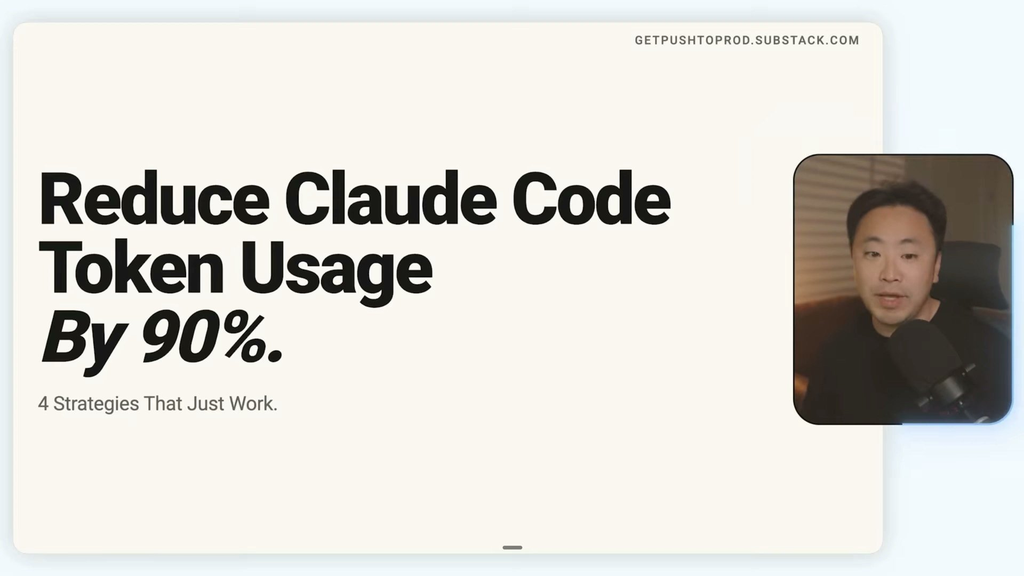

## Strategy 1: Index the Code with CodeGraph

The first strategy is to **index the code** — create an index of the codebase. If you don’t know what indexing is, search is a famous use of an index: what Google does behind the scenes is create a map of keywords pointing to different websites (a very dumbed-down example). The core idea is to create a **graph map** of our codebase.

### Grep and Scan vs Query the Graph

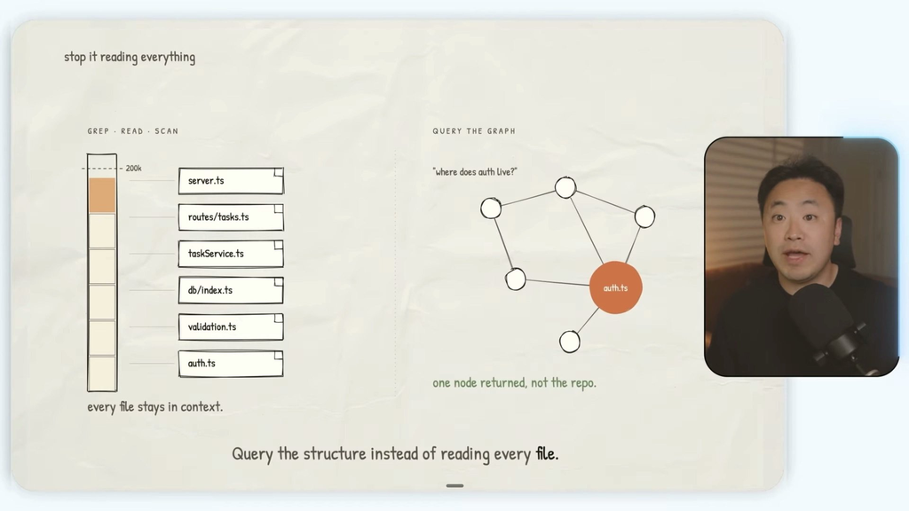

On the left is how Claude Code already does grep-read-scan: it goes one by one and deep-dives into the codebase. If you ask about some server implementation, a validation file, or an auth file, it greps with regular file search, finds it, and loads those into the token context. It ends up spending a lot of time, because to find the files it’s looking for, it reads a lot of things it doesn’t need.

When you **index the entire codebase into a queryable graph**, you use natural language to find the code via search. You do this indexing ahead of time, once, so Claude Code can leverage the code graph to find things under the hood **without reading all those other files** just to get where it needs to go.

### Using CodeGraph

The way to get this working is a repo called **CodeGraph**. It’s very easy to install — copy the `npx` command and paste it in, or install with `npm` globally, then init the project:

```
codegraph init -i
```

There’s a bunch you can do with it. For example, `codegraph status` gives you metadata about the graph — what’s in there, what kinds of nodes exist (imports, components, the common things you’d need).

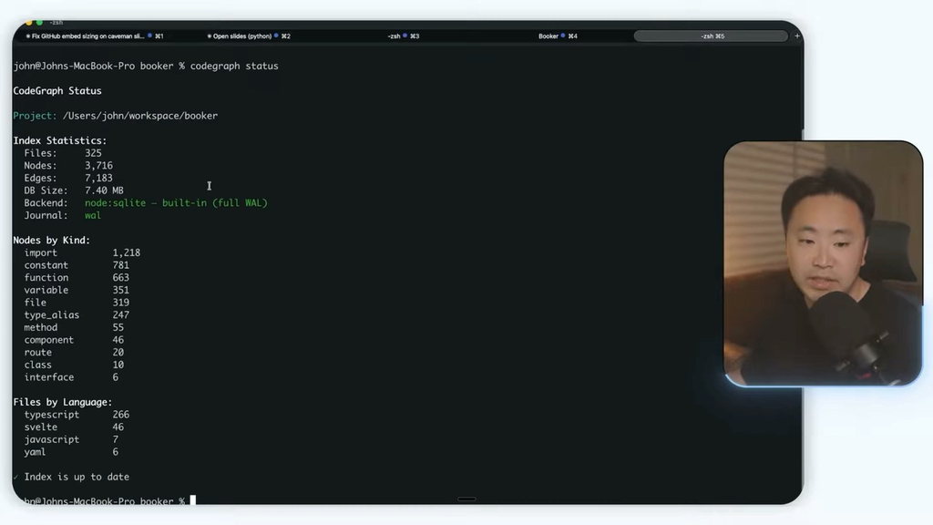

As an example, we could run a query — `codegraph query lm` — and it finds two search results (an HTML-to-text and an active session). You essentially use semantic, natural language to find the relevant code. You wouldn’t normally use this manually, but **Claude Code learns to use this CLI tool under the hood** and does all of these functions for you.

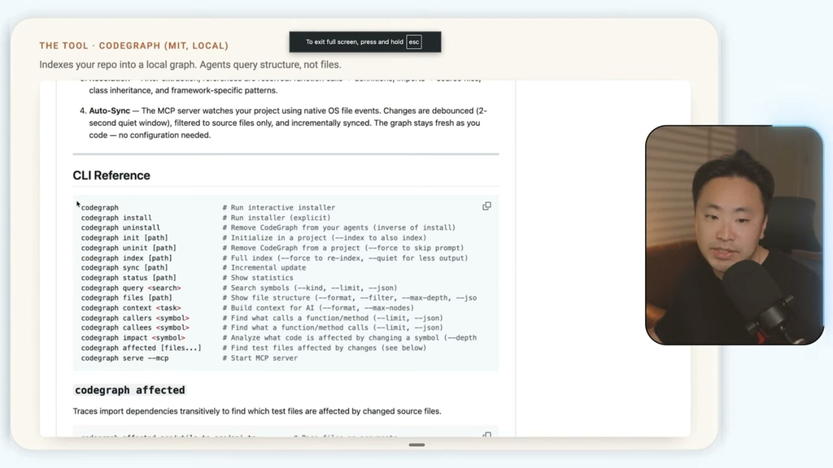

If you look at the docs, there’s a full CLI reference. Claude Code reads the CLI tool, understands how to use it, and leverages it to do the queries. So that’s the first strategy: instead of Claude Code reading files one by one with grep, you do some work ahead of time, index a bunch of things, and get to the file you’re looking for more semantically. This is a very common strategy — it’s how a lot of search-based products and graph recommendations (like at Meta) work.

### Trade-offs of Indexing

But there are trade-offs:

- **Two sources of truth.** Your codebase is one source of truth; now the index is another. Some system — ideally Claude Code — has to spend time **syncing**. This repo has a sync method, but if you forget to run it, or it hasn’t run in a while, something can go out of sync. Then Claude Code will confidently be wrong: “this function doesn’t exist” (when it does), or “this file exists” (when it doesn’t). There’s a tax to keeping it synced.
- **Module-level `CLAUDE.md` can be missed.** Normally, when Claude reads a file in a directory, it goes up and reads that module’s `CLAUDE.md`. But with the query/index path, the semantic code search may find the file it needs yet **miss that module’s `CLAUDE.md`** that would normally load. This matters for compound-engineering setups with context files in big modules.
- **Accuracy on deep dives**, and at the end of the day you still need to **read the actual file once** you find where it is. So you save a lot of tokens on *retrieval*, but you still spend tokens *reading* the file.

## Strategy 2: Compress the Outputs with RTK

*[~5:30]*

Strategy two is to **compress the outputs**. Anyone who has programmed for a while knows that server logs, CLI logs, or just logs in general are very noisy — and often it’s information Claude Code doesn’t actually need.

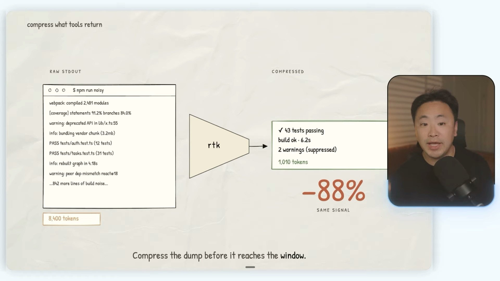

It’s easy to install (I just used Homebrew), into a specific directory or globally, and there are CLI commands to trigger it manually. This is a common pattern: a lot of people have realized that **CLIs are a better form factor than MCPs** — if they can build a CLI over an MCP, they will, because Claude Code is very good at juggling CLIs.

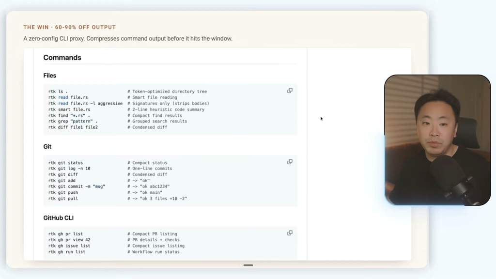

A simple example: a plain `git log` goes on for a while with a ton of information. Run it through RTK and it’s compressed, showing how many lines were omitted — saving a ton of tokens. And like CodeGraph, Claude Code will leverage this tooling on your behalf.

### Trade-off: Lossy Compression

The trade-off here is obvious: **accuracy**, because the compression is **lossy**. You have a chance of dropping an important log or message you were hoping for. The system tries its best to remove only what it doesn’t need, but if you’re debugging a bunch of server logs it might be worth turning this off for that specific work. Know when to turn it on and off — for self-healing/self-correction, you may want the full system logs to verify each step. But most of the time you don’t need all the logs, so this is a great strategy to compress the output before it reaches you.

## Strategy 3: Make Claude Talk Less with caveman

*[~9:15]*

Strategy three is my favorite — and honestly I think it’s misnamed. It’s an open-source library called **caveman**, and at a high level it gets Claude Code to **talk less**.

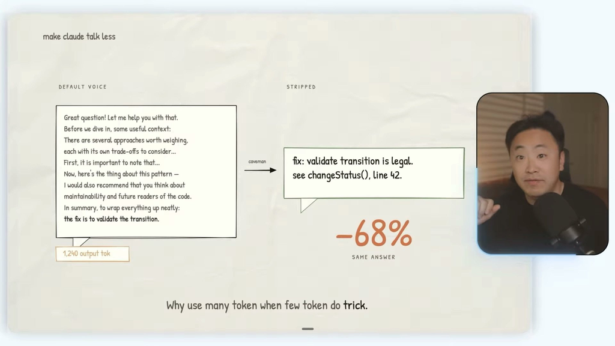

I want to show this with the most accurate assessment of what it’s doing — *“Why waste time say lot word when few word do trick.”* That’s one of my favorite clips from The Office; Kevin was ahead of his time, definitely a Claude Code maxxer. So caveman (probably should’ve been named “Kevin”) just shortens the amount of words Claude Code uses to say basically the same thing.

It’s very easy to install — `npm install`, copy the command, paste it into your bash. It’s a **skill** that sets your Claude Code session into a specific mode: **light, full, ultra, and wenyan**. It’s per session, so you can remove it or add it at any time.

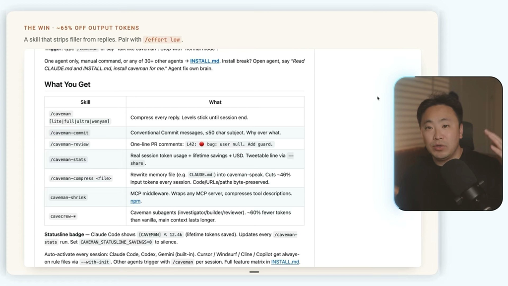

Let’s give it a shot: *“tell me about this project.”* On the left is without caveman; then caveman ultra comes on. As you can see, it’s about **half the output**, and I’d say you still get about the same quality — pretty accurate. I use it quite a bit and keep it on ultra until I need to get away from a specific trade-off.

### Trade-off: Context Quality

The obvious trade-off: yes, you save tokens, but **correctness is at risk**. Claude Code really leverages the feedback loop of messages in and out to get the context it needs to answer well. When you shrink the outputs dramatically, those messages get re-sent back to Claude Code — that’s how the context window and the agentic loop work, and how it knows what you’ve been working on. If the quality of your session’s context history is bad, the output may lead to bad answers.

> I’m working on a video on **system design for Claude Code** — I think system design is the most important thing in this new world of AI. It’s a whole series on agentic tools: building ChatGPT, building Claude Code, building a RAG system. If you’re interested, subscribe to the channel and newsletter.

## Strategy 4: Manage the Session

*[~12:20]*

### Context, Clear, and Model

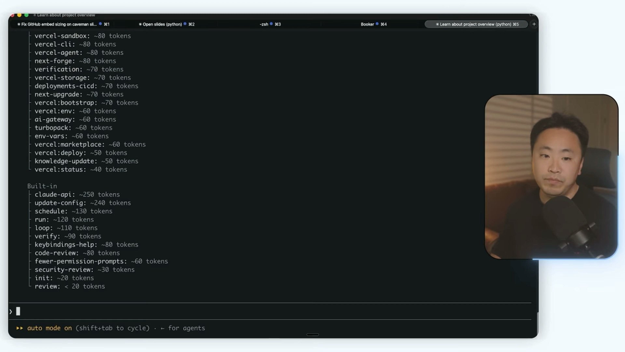

### Pro Tips

- **Pro tip:** for any significant programming task — especially planning and deep dives — be on the most **reliable** model. Quality itself is a token savings, versus trying to save money with a cheaper model and getting a bad result you have to redo.
- Use **plan mode first** to plan an execution rather than letting Claude Code go off and do a bunch of things.
- For programming in general, use **Pencil or Figma** to design something and work off designs, rather than coding something right away.

## Should You Use All of These?

*[~16:00]*

So should you use all of these things? In my opinion, **yes** — but again, there are trade-offs.

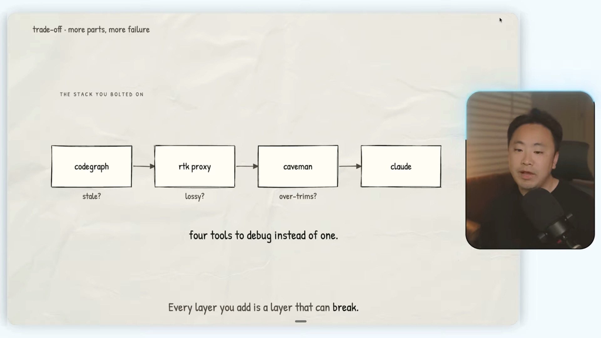

The largest trade-off is really **cost versus quality**, plus **complexity**. The code graph can get stale. The RTK proxy is lossy, so you’re straight up missing messages and might miss a log you need. And caveman may over-trim, so the message history isn’t great. But all of these dramatically save tokens. So it’s really about *you* understanding how to use these tools: “in this application I may not need all the logs, so I’ll have RTK on,” or “caveman is great here because I’m not doing a crazy plan-mode session right now.”

All of these add complexity — multiple layers, multiple things to juggle, multiple failure points for Claude Code. So use them at your own risk. But I guarantee you’ll save tokens using these strategies.

## Conclusion

I hope you enjoyed this video. I make a ton of videos on Claude Code and AI/agentic coding, so feel free to check them out, and subscribe to my newsletter for content I don’t post here. I also just launched a new **course with ByteByteGo** — a paid, two-day live course where you build portfolio projects and I teach you basically everything I know about Claude Code. If you’re interested, sign up via ByteByteGo’s newsletter or the course website (it may or may not have happened already; if you missed it, catch the next one).

> Until I see you guys on the next one — bye.

## Key Takeaways

| Strategy | What it does | Tool | The trade-off |
| --- | --- | --- | --- |
| **1 · Index the code** | Build a queryable graph so Claude *queries structure* instead of grepping and reading every file | **CodeGraph** (`codegraph`, MIT, local SQLite + MCP auto-sync) | Two sources of truth → can go **stale**; may miss a module’s `CLAUDE.md`; you still read the final file |
| **2 · Compress outputs** | A CLI proxy that shrinks noisy command/log output *before* it reaches the window (60–90% off) | **RTK** (`rtk` wraps files, git, gh) | **Lossy** — can drop a log you actually needed; turn it off when debugging |
| **3 · Make Claude talk less** | A skill that strips filler from replies (~65% off output), modes: lite/full/ultra/wenyan | **caveman** (`/caveman …`) | Shrinking outputs degrades the **context history** the agentic loop relies on |
| **4 · Manage the session** | Built-in hygiene: audit, clear, and right-size the model | `/context`, `/clear`, `/model`, plan mode | Cheap models on hard tasks cost more in rework — **quality is a token savings** |
| **Overall** | Stack them for big savings, but choose per task | — | **Cost vs quality + complexity**: four tools to debug instead of one; every layer can break |